# ⅩⅢ. 군집분석

ne_choi

2020 12 10

- POSTECH에서 제공하는 [MOOC](https://pabi.smartlearn.io/) 중, 머신러닝기법과 R프로그래밍 Ⅱ 과정입니다.

# ⅩⅢ. 군집분석

## 1. 군집분석과 유사성 척도

### 군집분석

- 군집분석은 비지도학습(Unsupervised Learning)
  - 주어진 데이터(X 변수들)의 속성으로 군집화
    - 계층형 군집 분석
    - k-means
- 유사한 속성을 가진 객체를 군집(cluster)으로 묶는 데이터 마이닝 기법
  - 예제: 고객 구매패턴을 반영하는 속성 데이터가 수집된다고 할 때, 군집분석을 통해 유사한 구매패턴을 보이는 고객을 군집화하고 판매전략을 도출(소득/충성정도 등)

### 군집분석 종류

1. 계층적 군집(Hierarchical Clustering)
   - 사전에 군집 수 k를 정하지 않고 단계적으로 군집 트를 제공
2. 비계층적 군집(Non-hierarchical Clustering)
   - 사전에 군집 수 k를 정한 후 각 객체를 k개 중 하나의 군집에 배정

### 유사성 척도

- 객체 간의 유사성 정도를 정량적으로 나타내기 위해 척도가 필요
  - 거리(distance) 척도
    - 거리가 가까울수록 유사성이 커짐
  - 상관계수척도
    - 객체 간 상관계수가 클수록 유사성이 커짐

```r
# similarity measures - distance
m1 <- matrix(
  c(150, 50, 130, 55, 80, 80, 100, 85, 95, 91),
  nrow = 5,
  ncol = 2,
  byrow = TRUE)
# m1 is a matrix
m1
```

```
##      [,1] [,2]
## [1,]  150   50
## [2,]  130   55
## [3,]   80   80
## [4,]  100   85
## [5,]   95   91
```

```r
is.data.frame(m1)
```

```
## [1] FALSE
```

```r
# m1 is defined as dataframe
m1<-as.data.frame(m1)
```

- **거리척도**
  - 객체 i의 p차원 공간에서의 좌표는 열벡터로 표현
    - p개의 속상을 가진 객체 i에 관해, j번째 속성은 X<sub>ji</sub>로 표현
  - 거리 계산 함수: dist(데이터, method= ), default는 “euclidean”
  1. 유클리디안 거리(Euclidean distance)
     - Distance = $\sqrt{(x~12~ - x~11~)^2^ + (x~21~ - x~22~)^2^}$

```r
# 1. Euclidean distance
D1 <- dist(m1)
D1
```

```
##          1        2        3        4
## 2 20.61553
## 3 76.15773 55.90170
## 4 61.03278 42.42641 20.61553
## 5 68.60029 50.20956 18.60108  7.81025
```

2. 민코프스키 거리(Minkowski distance
   - 유클리디안 거리의 일반화된 방법(m = 2일 때는 유클리디안 거리와 동일)
   - d(x<sub>i</sub>,x<sub>j</sub>) = (시그마|X<sub>ki</sub> - X<sub>kj</sub>|<sup>m</sup>)<sup>1/m</sup>

```r
# 2. Minkowski distance
D2<- dist(m1, method="minkowski", p=3)
D2
```

```
##           1         2         3         4
## 2 20.103629
## 3 71.790544 52.002096
## 4 55.164795 37.797631 20.103629
## 5 61.735957 44.736068 16.757812  6.986368
```

3. 마할라노비스 거리(Mahalanobis distance)
   - 변수 간의 상관관계가 존재할 때 사용
   - d(x<sub>i</sub>,x<sub>j</sub>) = $\sqrt{(x~i~ - x~j~)^T^S^-1^(x~i~ - x~j~)}$

### 상관계수를 유사성 척도로 사용

- 상관관계가 클수록 두 객체의 유사성이 크다고 추정

```r
# 3. correlation coefficient
m2 <- matrix(
  c(20, 6, 14, 30, 7, 15, 46, 4, 2),
  nrow = 3,
  ncol = 3,
  byrow = TRUE,
  dimnames = list(
     c("obs1", "obs2", "obs3"),
     c("age", "exp", "time")))
m2
```

```
##      age exp time
## obs1  20   6   14
## obs2  30   7   15
## obs3  46   4    2
```

- 상관계쑤 측정

```r
# correlation between Obs1~Obs2
cor(m2[1,],m2[2,])
```

```
## [1] 0.9673518
```

```r
# correlation between Obs1~Obs3
cor(m2[1,],m2[3,])
```

```
## [1] 0.7984081
```

- 결과 해석
  - 객체 1(obs1)과 객체 2의 유사성이, 객체 1과 객체 3 간 유사성보다 큼(0.9674 > 0.7984)

### 퀴즈

```r
# 2. Minkowski distance
D4<- dist(m1, method="manhattan")
D4
```

```
##     1   2   3   4
## 2  25
## 3 100  75
## 4  85  60  25
## 5  96  71  26  11
```

## 2. 계층적 군집분석

### 계측적 군집분석

- 사전에 군집 수 k를 정하지 않고 단계적으로 군집 형성
  - 유사한 객체를 군집으로 묶고, 그 군집을 기반으로 유사한 군집을 새로운 군집으로 묶어가면서 군집을 계층적으로 구성
  - 단일연결법(single linkage method)
  - 완전연결법(complete linkage method)
  - 평균연결법(average linkage method)
  - 중심연결법(centroid linkage method)

**1. 단일연결법** - 군집 i와 군집 j의 유사성 척도로 두 군집의 모든 객체 쌍의 거리 중 **가장 가까운 거리**를 사용 - 객체 쌍이 가장 짧은 거리가 유사할수록 두 군집이 더 유사하다고 평가

**2. 완전연결법** - 두 군집의 모든 객체 쌍의 거리 중 **가장 먼 거리**를 사용

**3. 평균연결법** - 두 군집의 모든 객체 쌍의 **평균 거리**를 사용

**4. 중심연결법** - 두 군집의 **중심 좌표** (무게 중심, 객체가 아닌 위치)

### 완전연결법 vs 평균연결법

- 데이터 설명
  - 1833년 영국 Lancashire 방직 공장 임금
  - DAAG package built in 데이터
  - 총 51개 객체
  - 객체별 5개 속성
    - 나이(age), 남성 근로자 수(mnum), 남성 근로자 평균 임금(mwage), 여성 근로자 수(fnum), 여성 근로자 평균 임금(fwage)

```r
# needs "lattice", "DAAG" package for loading dataset
# install.packages("lattice")
# install.packages("DAAG")
library(lattice)
library(DAAG)
```

- 데이터 불러오기(DAAG 패키지 안에 든 데이터)

```r
# read csv file
wages1833<-read.csv(file="data/week13_2/wages1833.csv")
head(wages1833)
```

```
##   X age mnum mwage fnum fwage
## 1 1  10  204  30.5  122    35
## 2 2  11  195  37.8  198    38
## 3 3  12  245  43.0  241    44
## 4 4  13  233  50.5  233    46
## 5 5  14  256  56.5  236    59
## 6 6  15  240  63.0  215    68
```

```r
# remove observations with the missing values
dat1<-wages1833
dat1<-na.omit(dat1)
str(dat1)
```

```
## 'data.frame':    51 obs. of  6 variables:
##  $ X    : int  1 2 3 4 5 6 7 8 9 10 ...
##  $ age  : int  10 11 12 13 14 15 16 17 18 19 ...
##  $ mnum : int  204 195 245 233 256 240 204 141 164 135 ...
##  $ mwage: num  30.5 37.8 43 50.5 56.5 ...
##  $ fnum : int  122 198 241 233 236 215 256 245 279 251 ...
##  $ fwage: int  35 38 44 46 59 68 72 78 90 98 ...
```

- 계층적 군집분석: hclust(거리계산결과, method=" ")

```r
# calculate distance between each nodes
dist_data<-dist(dat1)
```

1. 완전연결법 적용 결과(거리 계산은 유클리디안)

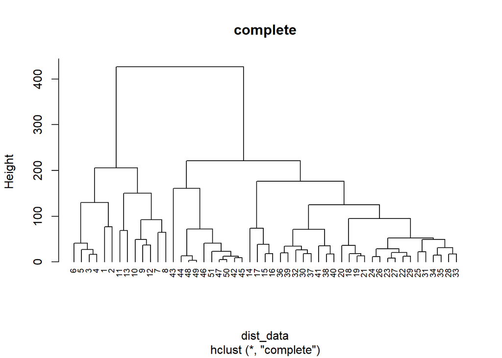

```r
# prepare hierarchical cluster
# complete linkage method
hc_a <- hclust(dist_data, method = "complete")
plot(hc_a, hang = -1, cex=0.7, main = "complete")
```

- 설명 - single: 단일, complete: 완전, average: 평균, centriod: 중심

2. 평균연결법 적용 결과(거리 계산은 유클리디안)

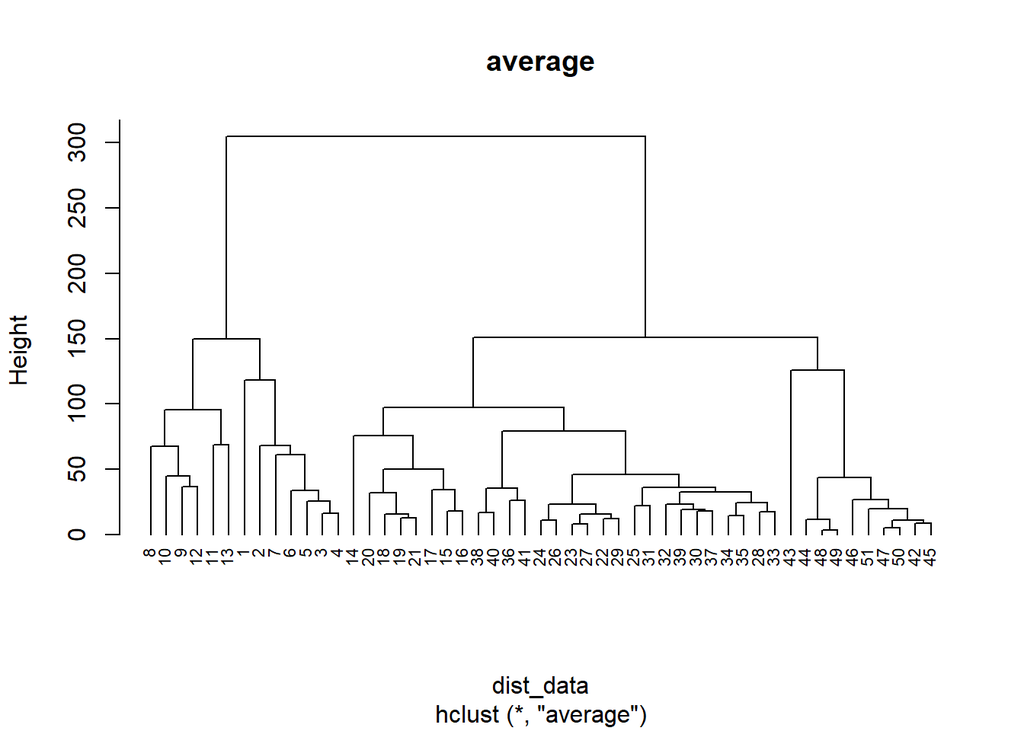

```r
# average linkage method
# check how different from complete method
hc_c <- hclust(dist_data, method = "average")
plot(hc_c, hang = -1, cex=0.7, main = "average")
```

### 와드 연결방법

- Ward’s method
- 많이 사용됨
3. 와드방법을 적용한 결과(거리계산은 유클리디안)

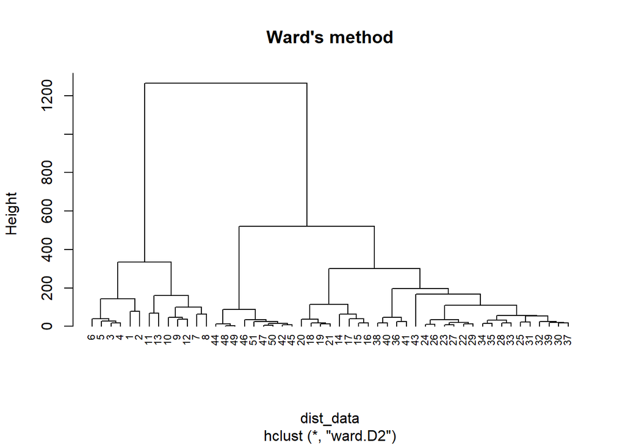

```r
# Ward's method
hc_c <- hclust(dist_data, method = "ward.D2")
plot(hc_c, hang = -1, cex=0.7, main = "Ward's method")
```

## 3. 비계층적 군집분석

### 비계층적 군집분석

- 사전에 군집 수 k를 정한 후, 각 객체를 k개 중 하나의 군집에 배정
  - 비계층적 군집(Non-hierarchical Clustering)
    - K-means 알고리즘
    - K-medoids 알고리즘
      - PAM(Partitioning Around Medoids)
      - CLARA(Clustering LARge Applications)

### k-means 군집분석

- 비계층적 군집분석 중 가장 널리 사용
  - k개 군집의 중심좌표를 고려하여 각 객체를 가장 가까운 군집에 배정하는 것을 반복
    - 0단계. 초기 객체 선정: k개 객체 좌표를 초기 군집 중심좌표로 선정
    - 1단계. 객체 군집 배정: 각 객체와 k개 중심좌표와의 거리 산출 후, 가장 가까운 군집에 객체 배정
    - 2단계. 군집 중심좌표 산출: 새로운 군집의 중심좌표 산출
    - 3단계. 수렴 조건 점검: 새로 산출된 중심 좌표값과 이전 좌표값을 비교하여 수렴 조건 내에 들면 종료, 아니면 단계 1 반복

### k-means 군집분석 예제

- 데이터 불러오기

```r
# read csv file
wages1833<-read.csv(file="data/week13_3/wages1833.csv")
head(wages1833)
```

```
##   X age mnum mwage fnum fwage
## 1 1  10  204  30.5  122    35
## 2 2  11  195  37.8  198    38
## 3 3  12  245  43.0  241    44
## 4 4  13  233  50.5  233    46
## 5 5  14  256  56.5  236    59
## 6 6  15  240  63.0  215    68
```

```r
# preprocessing
dat1<-wages1833
dat1<-na.omit(dat1)
head(dat1, n=5)
```

```
##   X age mnum mwage fnum fwage
## 1 1  10  204  30.5  122    35
## 2 2  11  195  37.8  198    38
## 3 3  12  245  43.0  241    44
## 4 4  13  233  50.5  233    46
## 5 5  14  256  56.5  236    59
```

- 군집수 k결정
  - 최적 군집수에 관한 시각화
  - 최적값은 “silhouette(실루엣)”, “gap_stat”, “wss(그룹내합계제곱)”으로 산출
  - 그래프가 완만해지는 지점을 k의 값으로 추정

```r
# to choose the optimal k
# install.packages("factoextra")
library(factoextra)
```

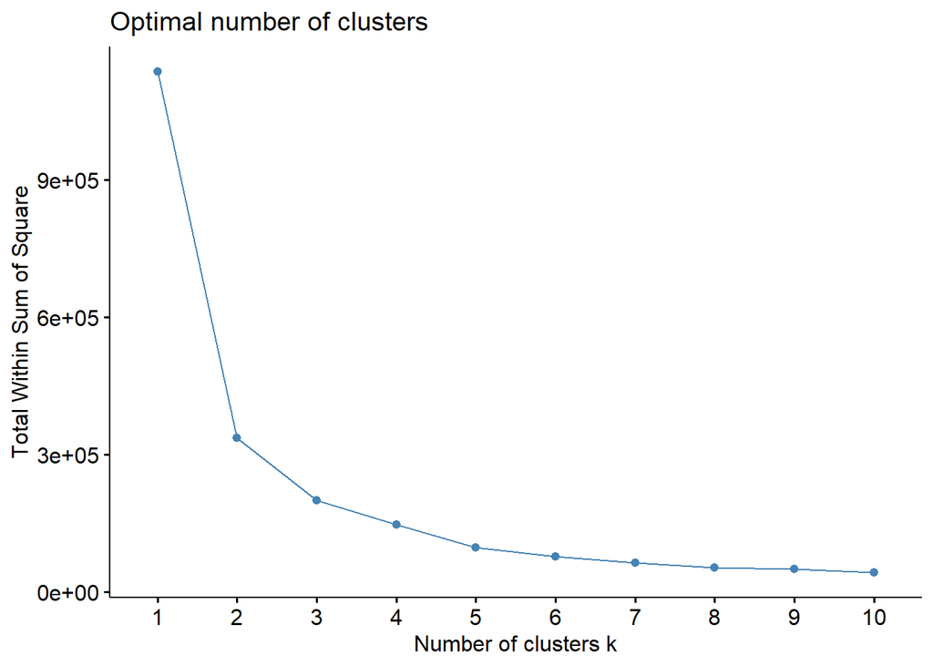

```r
fviz_nbclust(dat1, kmeans, method = "wss")
```

- 결과 해석 - 최적 k = 3

- k-means (k=3)

```r
# compute kmeans
set.seed(123,sample.kind="Rounding")
km <- kmeans(dat1, 3, nstart = 25) # random set의 수 (nstart)
km
```

```
## K-means clustering with 3 clusters of sizes 13, 10, 28
##
## Cluster means:
##      X  age     mnum     mwage      fnum    fwage
## 1  7.0 16.0 187.2308  96.36154 225.23077  71.0000
## 2 46.5 55.5   6.9000 178.99000   0.00000   0.0000
## 3 27.5 36.5  43.2500 241.73214  31.21429 107.9643
##
## Clustering vector:
##  1  2  3  4  5  6  7  8  9 10 11 12 13 14 15 16 17 18 19 20 21 22 23 24 25 26
##  1  1  1  1  1  1  1  1  1  1  1  1  1  3  3  3  3  3  3  3  3  3  3  3  3  3
## 27 28 29 30 31 32 33 34 35 36 37 38 39 40 41 42 43 44 45 46 47 48 49 50 51
##  3  3  3  3  3  3  3  3  3  3  3  3  3  3  3  2  2  2  2  2  2  2  2  2  2
##
## Within cluster sum of squares by cluster:
## [1] 94771.73 19142.37 86034.27
##  (between_SS / total_SS =  82.4 %)
##
## Available components:
##
## [1] "cluster"      "centers"      "totss"        "withinss"     "tot.withinss"
## [6] "betweenss"    "size"         "iter"         "ifault"
```

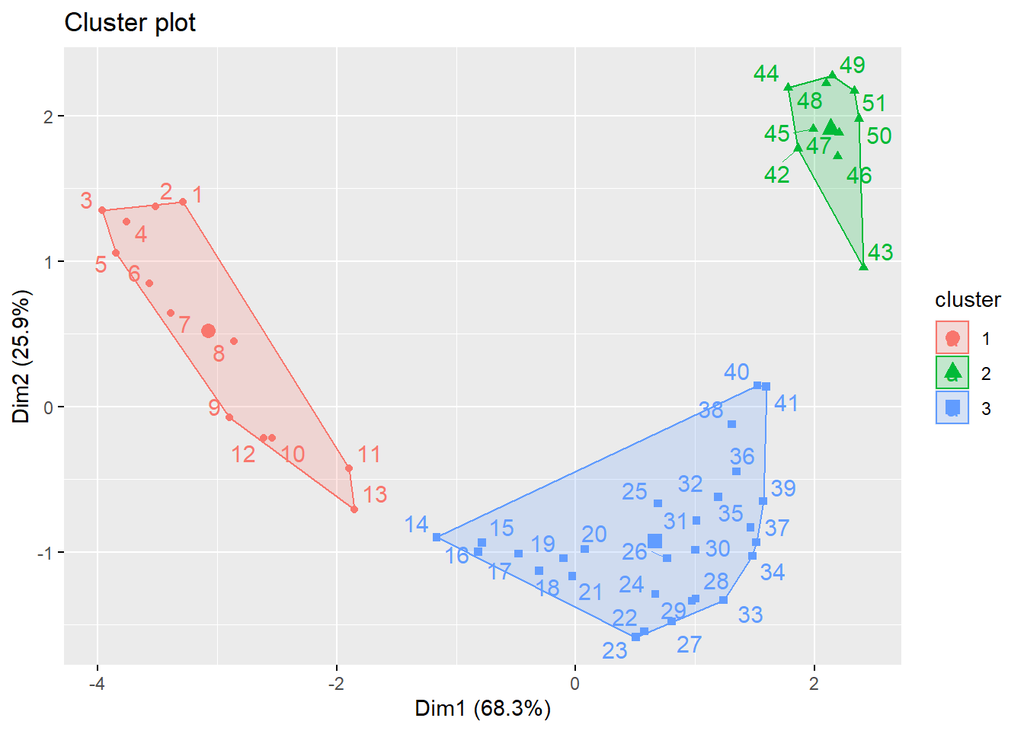

```r
# visualize
fviz_cluster(km, data = dat1,
             ellipse.type="convex", # Convex 모양으로 구역 표시
             repel = TRUE) # repel을 통해 관측치 표기
```

### K-medoids 군집분석

- K-medoids 군집분석은 각 군집의 대표 객체(medoid)를 고려
  - 군집의 대표 객체란, 군집 내 다른 객체들과의 거리가 최소가 되는 객체
  - K-medoids 군집분석은 객체를 k개의 군집으로 구분하는데, 객체와 속하는 군집의 대표 객체와의 거리 총합을 최소로 하는 방법
    - **PAM(Partitioning Around Medoids) 알고리즘**: 모든 객체에 관해 대표 객체가 변했을 때 발생하는 거리 총합의 변화를 계산, 데이터 수가 많아질수록 연산량이 크게 증가
    - **CLARA 알고리즘**: 적절한 수의 객체를 샘플링한 후, PAM 알고리즘을 적용해 대표 객체 선정, 샘플링을 여러 번 한 후 가장 좋은 결과를 선택, 편향된 샘플링은 잘못된 결괏값을 도출할 수 있음
- PAM 알고리즘 살펴보기

```r
# compute PAM
library("cluster")
pam_out <- pam(dat1, 3)
pam_out
```

```
## Medoids:
##    ID  X age mnum mwage fnum fwage
## 7   7  7  16  204  83.5  256    72
## 31 31 31  40   38 243.5   15   104
## 45 45 45  54   12 174.0    0     0
## Clustering vector:
##  1  2  3  4  5  6  7  8  9 10 11 12 13 14 15 16 17 18 19 20 21 22 23 24 25 26
##  1  1  1  1  1  1  1  1  1  1  1  1  1  2  2  2  2  2  2  2  2  2  2  2  2  2
## 27 28 29 30 31 32 33 34 35 36 37 38 39 40 41 42 43 44 45 46 47 48 49 50 51
##  2  2  2  2  2  2  2  2  2  2  2  2  2  2  2  3  3  3  3  3  3  3  3  3  3
## Objective function:
##    build     swap
## 57.67971 54.83640
##
## Available components:
##  [1] "medoids"    "id.med"     "clustering" "objective"  "isolation"
##  [6] "clusinfo"   "silinfo"    "diss"       "call"       "data"
```

```r
# freq of each cluster
table(pam_out$clustering)
```

```
##
##  1  2  3
## 13 28 10
```

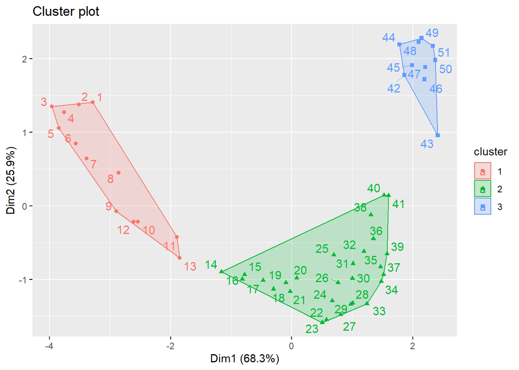

```r
# visualize
fviz_cluster(pam_out, data = dat1,
             ellipse.type="convex",
             repel = TRUE)
```